# Learning to Conduct RNASeq Analysis

This is an [R Markdown](http://rmarkdown.rstudio.com) Notebook meant for documenting the learning progress in BCB420. When code is executed within the notebook, the results appear beneath the code.

## Assignment 1: Data set selection and initial Processing

We want expression datasets that are: 1) with good **coverage**;  
2) not much older than ten years (**updated quality**);  
3) with sufficient numbers of **replicates**;  
4) collected under **interesting conditions**;  
5) mapped to unique human gene identifiers.

### Part 1: Learning to Conduct SQL Queries

```r
# Note: the full version of GEOmetadb.sqlite is a massive file of > 10GB, its compressed gz archive is 740MB. The full download + unzipping was taking TOO LONG in R, possibly due to my connection, so I downloaded the compressed file and manually unzipped it locally.
# citation("GEOmetadb")

options(timeout = 600)
if(!file.exists('GEOmetadb.sqlite')) getSQLiteFile(destdir="/home/rstudio/projects/bcb420_code")

# View file info
file.info('Geometadb.sqlite')
```

|  | size | isdir | mode | mtime | ctime | atime | uid | gid | uname | grname |
| --- | --- | --- | --- | --- | --- | --- | --- | --- | --- | --- |
| Geometadb.sqlite | 13223856128 | FALSE | 644 | 2022-02-03 20:05:57 | 2022-02-03 20:06:32 | 2022-02-03 20:05:57 | 501 | 20 | apple | staff |

```r
con <- dbConnect(SQLite(), 'GEOmetadb.sqlite')
# View list of tables
geo_tables <- dbListTables(con)
geo_tables
```

```
##  [1] "gds"               "gds_subset"        "geoConvert"
##  [4] "geodb_column_desc" "gpl"               "gse"
##  [7] "gse_gpl"           "gse_gsm"           "gsm"
## [10] "metaInfo"          "sMatrix"
```

```r
# View an individual table (*this one has supplementary_file)
dbListFields(con, "gse")
```

```
##  [1] "ID"                   "title"                "gse"
##  [4] "status"               "submission_date"      "last_update_date"
##  [7] "pubmed_id"            "summary"              "type"
## [10] "contributor"          "web_link"             "overall_design"
## [13] "repeats"              "repeats_sample_list"  "variable"
## [16] "variable_description" "contact"              "supplementary_file"
```

```r
# Preliminary SQL queries (*some of these datasets are over 20 years old)
results <- dbGetQuery(con,'select * from gpl limit 10')

# Over 20,000 experiments types (e.g. RNAseq/Microarray/Protein array)
num_platforms <- dbGetQuery(con,'select count(*) from gpl')
# 20 types of gpl associated information
dbListFields(con,'gpl')
```

```
##  [1] "ID"                   "title"                "gpl"
##  [4] "status"               "submission_date"      "last_update_date"
##  [7] "technology"           "distribution"         "organism"
## [10] "manufacturer"         "manufacture_protocol" "coating"
## [13] "catalog_number"       "support"              "description"
## [16] "web_link"             "contact"              "data_row_count"
## [19] "supplementary_file"   "bioc_package"
```

```r
# 18 unique technologies (where is RNAseq? Terminology mix up)
uniq_tech <- dbGetQuery(con,'select distinct technology from gpl')
# length(uniq_tech)

# How many platforms (experiment types) are associated with each technology?
species_ids <- dbGetQuery(con, 'select organism, count(*) as num_plat from gpl where organism like "%homo%" group by organism order by num_plat desc')
knitr::kable(species_ids[1:5,], format="html")
```

| organism | num_plat |
| --- | --- |
| Homo sapiens | 5349 |
| Homo sapiens; Mus musculus; Rattus norvegicus | 121 |
| Homo sapiens; Mus musculus | 70 |
| HomoÂ sapiens | 25 |
| Caenorhabditis elegans; Drosophila melanogaster; Danio rerio; Homo sapiens; Mus musculus; Rattus norvegicus | 19 |

```r
# List view ("contains human" tech)
num_uniq_tech_human <- dbGetQuery(con,'select technology,count(*) as num_plat from gpl where organism like "%Homo sapiens%" group by technology order by num_plat desc')
colnames(num_uniq_tech_human)[2] <- "Num_Platforms"
knitr::kable(num_uniq_tech_human, format = "html")
```

| technology | Num_Platforms |
| --- | --- |
| in situ oligonucleotide | 2424 |
| spotted DNA/cDNA | 1167 |
| spotted oligonucleotide | 1067 |
| RT-PCR | 382 |
| high-throughput sequencing | 318 |
| other | 204 |
| oligonucleotide beads | 197 |
| spotted peptide or protein | 121 |
| antibody | 41 |
| SAGE NlaIII | 4 |
| MPSS | 3 |
| mixed spotted oligonucleotide/cDNA | 2 |
| MS | 2 |
| tissue | 1 |
| SAGE Sau3A | 1 |

```r
# Query for RNAseq data by specifying tags
# Note in Journal: learned  correct syntax for combining OR & AND operators
sql_string <- paste("SELECT DISTINCT gse.title,gse.gse, gpl.title,",
             " gse.submission_date,",
             " gse.supplementary_file",
             "FROM",
             "  gse JOIN gse_gpl ON gse_gpl.gse=gse.gse",
             "  JOIN gpl ON gse_gpl.gpl=gpl.gpl",
             "WHERE",
             "  gse.submission_date > '2018-01-01' AND",
             "  gpl.organism LIKE '%Homo sapiens%' AND",
             "  gpl.technology LIKE '%high-throughput sequencing%' AND",
             "  (gse.title LIKE '%stem cell%' OR",
             "  gse.title LIKE '%muscle%' OR",
             "  gse.title LIKE '%regeneration%' )",
             "  ORDER BY gse.submission_date DESC",sep=" ")
rs <- dbGetQuery(con,sql_string)
# break the file names up and just get the actual file name
unlist(lapply(rs$supplementary_file,
              FUN = function(x){x <- unlist(strsplit(x,";")) ;
              x <- x[grep(x,pattern="txt",ignore.case = TRUE)];
                tail(unlist(strsplit(x,"/")),n=1)})) [1:10]
```

```
##  [1] "GSE165627_Normalized.txt.gz"
##  [2] "GSE165242_iPSCs-and-iPSC-CMs_mRNA_Data.txt.gz"
##  [3] "GSE165200_pg-2020-hsae-cov-expr.txt.gz"
##  [4] "GSE164644_logCPM_allsamples.txt.gz"
##  [5] "GSE164692_RNAseq_expressionMatrix_counts.txt.gz"
##  [6] "GSE164545_protein_network_diagram_CTRL_vs_CP2A.txt.gz"
##  [7] "GSE164081_TSS_tag_cluster_annotation.txt.gz"
##  [8] "GSE164081_TSS_tag_cluster_annotation.txt.gz"
##  [9] "GSE164081_TSS_tag_cluster_annotation.txt.gz"
## [10] "GSE163148_CombineAlignments_CA.rpm.bcmatrix.txt.gz"
```

```r
# Retrieve samples with counts data that are of interest
counts_files <- as.data.frame(rs$supplementary_file[grep(rs$supplementary_file,
                                                    pattern = "count",ignore.case = TRUE)])
colnames(counts_files) <- "supplementary_file"
names(rs)[1] <- "experiment"
rs_interest <- inner_join(rs, counts_files, by = "supplementary_file")
rs_interest[1:6,]
```

|  | experiment | gse | title | submission_date | supplementary_file |
| --- | --- | --- | --- | --- | --- |
| 1 | Eradication of donor-dependent variations of mesenchymal stem cells in immunomodulation to enhance their therapeutic values. | GSE165811 | Illumina HiSeq 2500 (Homo sapiens) | 2021-01-29 | ftp://ftp.ncbi.nlm.nih.gov/geo/series/GSE165nnn/GSE165811/suppl/GSE165811_counts.csv.gz |
| 2 | Prednisolone rescues Duchenne Muscular Dystrophy phenotypes in human pluripotent stem cells-derived skeletal muscle in vitro | GSE164874 | Illumina NextSeq 500 (Homo sapiens) | 2021-01-14 | ftp://ftp.ncbi.nlm.nih.gov/geo/series/GSE164nnn/GSE164874/suppl/GSE164874_DMD_VS_WT_Results.xlsx;\tftp://ftp.ncbi.nlm.nih.gov/geo/series/GSE164nnn/GSE164874/suppl/GSE164874_DMD_WT_raw_counts.xlsx;\tft… |
| 3 | Unravelling Heterogeneity of Amplified Human Amniotic Fluid Stem Cells Sub-Populations | GSE164692 | Illumina NextSeq 500 (Homo sapiens) | 2021-01-12 | ftp://ftp.ncbi.nlm.nih.gov/geo/series/GSE164nnn/GSE164692/suppl/GSE164692_RNAseq_expressionMatrix_counts.txt.gz |
| 4 | Expression profiling by high throughput sequencing for human induced pluripotent stem cells (iPSCs) derived astrocytes | GSE164545 | BGISEQ-500 (Homo sapiens) | 2021-01-11 | ftp://ftp.ncbi.nlm.nih.gov/geo/series/GSE164nnn/GSE164545/suppl/GSE164545_Raw_gene_counts_matrix.txt.gz;\tftp://ftp.ncbi.nlm.nih.gov/geo/series/GSE164nnn/GSE164545/suppl/GSE164545_correlation_heat_map… |
| 5 | Skeletal Muscle Transcriptome in Healthy Aging | GSE164471 | Illumina HiSeq 2500 (Homo sapiens) | 2021-01-08 | ftp://ftp.ncbi.nlm.nih.gov/geo/series/GSE164nnn/GSE164471/suppl/GSE164471_GESTALT_Muscle_ENSG_counts_annotated.csv.gz;\tftp://ftp.ncbi.nlm.nih.gov/geo/series/GSE164nnn/GSE164471/suppl/GSE164471_GESTAL… |
| 6 | Anabolic effects of cheddar cheese consumption in human skeletal muscle | GSE163279 | Illumina NovaSeq 6000 (Homo sapiens) | 2020-12-15 | ftp://ftp.ncbi.nlm.nih.gov/geo/series/GSE163nnn/GSE163279/suppl/GSE163279_RawCounts_Milk_Cheese_v1.xlsx;\tftp://ftp.ncbi.nlm.nih.gov/geo/series/GSE163nnn/GSE163279/suppl/GSE163279_foldchange_Milk_Chee… |

```r
# print(rs_interest, row.names = FALSE)
```

### Part 2: Dataset Information Report

From the aforementioned list of filtered search results, I selected a RNAseq dataset from a recent publication. See the short bio below for some basic information of dataset and its source.

Now I will proceed to peruse the literature to review the completeness of the dataset. (Are experimental approaches, analysis methods, and samples annotations well documented?)

```r
# Review selected dataset and its meta info
gse_chosen <- invisible(getGEO("GSE164471", GSEMatrix = FALSE))
gse_chosen_info <- data.frame(head(Meta(gse_chosen)))

current_gpl <- names(GPLList(gse_chosen))[1]
current_gpl_info <- Meta(getGEO(current_gpl))
```

#### Platform Meta Info

**Platform title** : Illumina HiSeq 2500 (Homo sapiens)  
**Submission data** : Mar 14 2013  
**Last update data** : Mar 27 2019 **Organism** : Homo sapiens (taxid: 9606)  
**Number of GEO datasets that use this technology** : 9230  
**Number of GEO samples that use this technology** : 262089

#### Dataset Meta Info

**Contact Location** : 251 Bayview Blvd,Baltimore,USA  
**Contact Institute** : NIA-IRP, NIH  
**Contact Department** : Laboratory of Genetics and Genomics  
**Contact Laboratory** : Computational Biology & Genomics Core

There are two supplemental files in this dataset:  
1). Genes/RNAs (ENSG) — GSE164471_GESTALT_Muscle_ENSG_counts_annotated.csv  
2). Transcripts/isoforms (ENST) — GSE164471_GESTALT_Muscle_ENST_TPM_annotated.csv  
In this study, the authors defined ENSGs as genes/RNAs and ENSTs as transcripts/isoforms.For the purpose of our analysis, we will focus on the RNA data file.

#### Personal Interest

I have a personal interest in biological aging and the development of tissue regenerative therapies. Unlike most aging-oriented studies that compare injured/diseased groups to a healthy control, this study aimed to elucidate differences in the transcriptomic network of healthy skeletal muscle as a function of age. This unique design removed the confounding variable of disease and focused on highlighting the mechanisms that drive changes in the expression of genes with aging and acquiring an understanding of both damage accumulation and strategies of biological resilience. These can serve as potential targets for clinical interventions.

```r
# Retrieve the data
# (there is a 14GB raw tar file associated with this data, exclude that from download)
if (!exists('sfiles'))
  sfiles <- getGEOSuppFiles('GSE164471', filter_regex = "csv")
fnames <- rownames(sfiles)

# Sizable data containing 57773 protein-coding and non-coding RNAs across 53 healthy individuals (22-83 years old)
RNAfile <- read.csv("GSE164471/GSE164471_GESTALT_Muscle_ENSG_counts_annotated.csv", check.names = FALSE)

# Notice how long each column name is. Each representing a study participant. We can see from the column names that column 2 ~ 54 represent individual study participant (the first column contains the ensemble IDs). BEWARE that the last 10 columns contain other info regarding RNAs in the Ensembl hg19 v82 (September 2015) database.
head(RNAfile)
```

|  | Tracking_ID | MUSCLE_AGE22_M_GROUP20_34_CC_T415_Gt073_R1_COUNT | MUSCLE_AGE23_M_GROUP20_34_CC_T293_Gt022_R1_COUNT | MUSCLE_AGE25_F_GROUP20_34_CC_T430_Gt085_R1_COUNT | MUSCLE_AGE25_M_GROUP20_34_AS_T355_Gt046_R1_COUNT | MUSCLE_AGE26_F_GROUP20_34_CC_T370_Gt051_R1_COUNT | MUSCLE_AGE26_F_GROUP20_34_CC_T400_Gt045_R1_COUNT | MUSCLE_AGE27_F_GROUP20_34_CC_T385_Gt055_R1_COUNT | MUSCLE_AGE28_M_GROUP20_34_CC_T326_Gt001_R1_COUNT | MUSCLE_AGE31_F_GROUP20_34_AS_T640_Gt090_R1_COUNT | MUSCLE_AGE31_M_GROUP20_34_AA_T230_Gt025_R1_COUNT | MUSCLE_AGE31_M_GROUP20_34_AA_T328_Gt005_R1_COUNT | MUSCLE_AGE33_M_GROUP20_34_CC_T340_Gt042_R1_COUNT | MUSCLE_AGE35_M_GROUP35_49_CC_T670_Gt104_R1_COUNT | MUSCLE_AGE37_F_GROUP35_49_AA_T120_Gt037_R1_COUNT | MUSCLE_AGE37_M_GROUP35_49_AA_T460_Gt064_R1_COUNT | MUSCLE_AGE38_M_GROUP35_49_CC_T232_Gt016_R1_COUNT | MUSCLE_AGE38_M_GROUP35_49_CC_T743_Gt093_R1_COUNT | MUSCLE_AGE42_F_GROUP35_49_CC_T445_Gt059_R1_COUNT | MUSCLE_AGE42_M_GROUP35_49_AA_T297_Gt024_R1_COUNT | MUSCLE_AGE45_M_GROUP35_49_AA_T292_Gt030_R1_COUNT | MUSCLE_AGE45_M_GROUP35_49_AA_T325_Gt017_R1_COUNT | MUSCLE_AGE47_F_GROUP35_49_CC_T490_Gt078_R1_COUNT | MUSCLE_AGE47_M_GROUP35_49_AA_T475_Gt060_R1_COUNT | MUSCLE_AGE51_M_GROUP50_64_CC_T289_Gt015_R1_COUNT | MUSCLE_AGE52_F_GROUP50_64_AA_T535_Gt063_R1_COUNT | MUSCLE_AGE52_F_GROUP50_64_CC_T331_Gt027_R1_COUNT | MUSCLE_AGE52_M_GROUP50_64_AA_T505_Gt056_R1_COUNT | MUSCLE_AGE52_M_GROUP50_64_CC_T329_Gt007_R1_COUNT | … |
| --- | --- | --- | --- | --- | --- | --- | --- | --- | --- | --- | --- | --- | --- | --- | --- | --- | --- | --- | --- | --- | --- | --- | --- | --- | --- | --- | --- | --- | --- | --- |
| 1 | ENSG00000000003 | 30 | 57 | 138 | 81 | 98 | 192 | 105 | 398 | 166 | 117 | 122 | 198 | 44 | 156 | 78 | 113 | 121 | 75 | 133 | 138 | 130 | 122 | 146 | 124 | 69 | 84 | 152 | 58 | … |
| 2 | ENSG00000000005 | 35 | 14 | 0 | 2 | 9 | 11 | 4 | 24 | 7 | 4 | 269 | 6 | 6 | 58 | 1 | 3 | 14 | 12 | 0 | 10 | 4 | 12 | 2 | 5 | 72 | 0 | 39 | 6 | … |
| 3 | ENSG00000000419 | 68 | 302 | 249 | 262 | 264 | 308 | 121 | 642 | 204 | 249 | 302 | 160 | 153 | 197 | 212 | 260 | 251 | 269 | 660 | 302 | 220 | 188 | 297 | 338 | 68 | 229 | 418 | 271 | … |
| 4 | ENSG00000000457 | 191 | 370 | 587 | 499 | 449 | 401 | 293 | 1251 | 574 | 329 | 463 | 500 | 285 | 365 | 320 | 378 | 685 | 679 | 807 | 600 | 453 | 481 | 484 | 617 | 336 | 237 | 965 | 321 | … |
| 5 | ENSG00000000460 | 209 | 430 | 471 | 353 | 330 | 324 | 239 | 934 | 397 | 251 | 430 | 422 | 256 | 305 | 224 | 364 | 373 | 504 | 711 | 468 | 341 | 431 | 337 | 524 | 240 | 207 | 759 | 251 | … |
| 6 | ENSG00000000938 | 65 | 25 | 23 | 25 | 49 | 35 | 38 | 8 | 2 | 17 | 12 | 57 | 111 | 19 | 23 | 22 | 25 | 35 | 14 | 16 | 2 | 25 | 38 | 13 | 27 | 25 | 78 | 5 | … |

```r
colnames(RNAfile)
```

```
##  [1] "Tracking_ID"
##  [2] "MUSCLE_AGE22_M_GROUP20_34_CC_T415_Gt073_R1_COUNT"
##  [3] "MUSCLE_AGE23_M_GROUP20_34_CC_T293_Gt022_R1_COUNT"
##  [4] "MUSCLE_AGE25_F_GROUP20_34_CC_T430_Gt085_R1_COUNT"
##  [5] "MUSCLE_AGE25_M_GROUP20_34_AS_T355_Gt046_R1_COUNT"
##  [6] "MUSCLE_AGE26_F_GROUP20_34_CC_T370_Gt051_R1_COUNT"
##  [7] "MUSCLE_AGE26_F_GROUP20_34_CC_T400_Gt045_R1_COUNT"
##  [8] "MUSCLE_AGE27_F_GROUP20_34_CC_T385_Gt055_R1_COUNT"
##  [9] "MUSCLE_AGE28_M_GROUP20_34_CC_T326_Gt001_R1_COUNT"
## [10] "MUSCLE_AGE31_F_GROUP20_34_AS_T640_Gt090_R1_COUNT"
## [11] "MUSCLE_AGE31_M_GROUP20_34_AA_T230_Gt025_R1_COUNT"
## [12] "MUSCLE_AGE31_M_GROUP20_34_AA_T328_Gt005_R1_COUNT"
## [13] "MUSCLE_AGE33_M_GROUP20_34_CC_T340_Gt042_R1_COUNT"
## [14] "MUSCLE_AGE35_M_GROUP35_49_CC_T670_Gt104_R1_COUNT"
## [15] "MUSCLE_AGE37_F_GROUP35_49_AA_T120_Gt037_R1_COUNT"
```

[output cut: 49 more lines]

```r
# Number of study participants we have : (53)
length(grep(colnames(RNAfile), pattern = "MUSCLE",ignore.case = TRUE))
```

```
## [1] 53
```

```r
# Number of unique genes we have measurements for: (57773)
dim(RNAfile)
```

```
## [1] 57773    64
```

```r
length(unique(RNAfile$Tracking_ID))
```

```
## [1] 57773
```

#### Experiment Info

- The sizable RNA data contains **57773 protein-coding and non-coding RNAs** across **53 healthy individuals (22-83 years old)**
  - Skeletal muscle biopsies gathered from 53 “very healthy” participants of the *GESTALT* study (Genetic and Epigenetic Signatures of Translational Aging Laboratory Testing carried out by the NIH) Criteria for sample inclusion was strict: Participants were excluded from the study if they consumed medication for chronic illness, trained professionally, had a body mass index ≥ 30 kg/m2, or were diagnosed with cognitive damage, a physical impairment, or a major disease.
  - The exact sample size (n) for each experimental group/condition, is given as a discrete number and unit of measurement: **(22–52 years, n = 28; 53–83 years, n = 25)**
  - Measurements were taken from biologically distinct samples, while RNA detection was conducted using the *Ensembl hg19 v82 (September 2015)* database repeatedly, and an average result was taken.

### Part 3: Gene Identifier Mapping and Filter

This section will generate the HGNC symbol mapping for each Ensembl ID in the data using 2.48.3.

- **HGNC symbol** is associated with most human protein-coding genes according to the HUGO Gene Nomenclature Committee.
- **Ensembl ID** is a way for the database to label features such as genes, transcripts, exons or proteins. They aim to be unambiguous and consistent across Ensembl releases. Unlike gene names/symbols which can change as a result of improved scientific knowledge, gene IDs continue to refer to the same genomic features. *They can sometimes be outdated.*
- Aside from deprecated ones, it is possible for some gene IDs to lack an associated HGNC symbol. In this case: non protein-coding RNA are given names from databases like miRBase (MicroRNAs) or Rfam (info about ncRNAs families). ‘Clone-based’ identifiers also apply to transcripts that cannot be associated with an HGNC symbol. This information is referenced from [HGNC Guidelines](https://www.genenames.org/about/guidelines/)

```r
if(!exists('ensembl')){
  ensembl <- useMart(biomart = "ensembl", dataset="hsapiens_gene_ensembl")
}
if(!exists('geneID_map')){
  geneID_map <- getBM(attributes = c('ensembl_gene_id', 'hgnc_symbol'),
                                 filters = 'ensembl_gene_id',
                                 values = RNAfile$Tracking_ID,
                                 mart = ensembl)
}

dim(geneID_map)
```

```
## [1] 52090     2
```

```r
# Unmapped genes
num_unmapped = nrow(RNAfile) - nrow(geneID_map)
unmapped <- anti_join(RNAfile[1], geneID_map[1], by = c("Tracking_ID" = "ensembl_gene_id"))
# - These unmapped identifiers will be removed from our analysis.
RNAfiltered <- inner_join(geneID_map, RNAfile, by = c("ensembl_gene_id" = "Tracking_ID"))

# Ensembl IDs that mapped to multiple HGNC symbols
E_occur <- data.frame(table(geneID_map$ensembl_gene_id))
# E_occur[E_occur$Freq > 1,]
# geneID_map[geneID_map$ensembl_gene_id %in% E_occur$Var1[E_occur$Freq > 1],]
# - One of the two HGNC symbols will be kept in this case. (the one documented in the current ensembl dataset)
# geneID_map <- geneID_map[!(geneID_map$hgnc_symbol=="LINC00856" | geneID_map$hgnc_symbol=="STRA6LP"),]
# - Update filtered RNA file
RNAfiltered <-
  RNAfiltered[!(RNAfiltered$hgnc_symbol=="LINC00856" | RNAfiltered$hgnc_symbol=="STRA6LP"),]

# HGNC symbols that mapped to multiple Ensemble IDs
# - As the table shows, 13 HGNC symbols have mapped to 2 Ensemble IDs, respectively
H_occur <- data.frame(table(geneID_map$hgnc_symbol))
# H_occur[H_occur$Freq > 1,]
# - Updated filter RNA file
# geneID_map <- geneID_map[!(geneID_map$hgnc_symbol==""), ]
RNAfiltered <- RNAfiltered[!(RNAfiltered$hgnc_symbol==""), ]
# geneID_map[geneID_map$hgnc_symbol %in% H_occur$Var1[H_occur$Freq > 1],]
# We will retain these 13 duplicated symbols for now using alternative naming.

### Counts Filtering
# Find n = 5 (GROUP 80 only contains 5 patients)
g20 <- ncol(RNAfiltered[,grepl( "GROUP20" , names(RNAfiltered))])
g35 <- ncol(RNAfiltered[,grepl( "GROUP35" , names(RNAfiltered))])
g50 <- ncol(RNAfiltered[,grepl( "GROUP50" , names(RNAfiltered))])
g65 <- ncol(RNAfiltered[,grepl( "GROUP65" , names(RNAfiltered))])
g80 <- ncol(RNAfiltered[,grepl( "GROUP80" , names(RNAfiltered))])
n <- min(g20, g35, g50, g65, g80)

keep = rowSums(RNAfiltered[2:54] >1) >= n
RNAfiltered = RNAfiltered[keep,]
dim(RNAfiltered)
```

```
## [1] 36084    65
```

```r
# this filtering method removed roughly 3000 genes, leaving 36084 gene mappings
rownames(RNAfiltered) <- make.names(RNAfiltered$hgnc_symbol, unique = TRUE)
```

First a gene mapping is produced using biomaRt package:

|  | ensembl_gene_id | hgnc_symbol |
| --- | --- | --- |
| 1 | ENSG00000000003 | TSPAN6 |
| 2 | ENSG00000000005 | TNMD |
| 3 | ENSG00000000419 | DPM1 |
| 4 | ENSG00000000457 | SCYL3 |
| 5 | ENSG00000000460 | C1orf112 |
| 6 | ENSG00000000938 | FGR |

> Unmapped genes:
- Initially, 5685 ensembl IDs were not found in the latest HUGO consortium.

  |  | Tracking_ID |
  | --- | --- |
  | 1 | ENSG00000005955 |
  | 2 | ENSG00000006074 |
  | 3 | ENSG00000006075 |
  | 4 | ENSG00000006114 |
  | 5 | ENSG00000017373 |
  | 6 | ENSG00000017621 |

- I looked up several ummapped RNAs in the current Ensembl database, which confirmed that these are outdated alias of human genes. e.g. *“Ensembl gene ENSG00000005955 is no longer in the database but it has been mapped to 1 deprecated identifier.”*
  - These unmapped identifiers are subsequently removed from this analysis.

> Ensembl IDs that mapped to multiple HGNC symbols:
- According to the frequency table, 2 Ensembl IDs have mapped to 2 HGNC symbols, respectively:

  |  | Var1 | Freq |
  | --- | --- | --- |
  | 29392 | ENSG00000230417 | 2 |
  | 42307 | ENSG00000254876 | 2 |

  |  | ensembl_gene_id | hgnc_symbol |
  | --- | --- | --- |
  | 29392 | ENSG00000230417 | LINC00856 |
  | 29393 | ENSG00000230417 | LINC00595 |
  | 42308 | ENSG00000254876 | SUGT1P4-STRA6LP |
  | 42309 | ENSG00000254876 | STRA6LP |

- Of which, **ENSG00000230417** points to a non-protein coding RNA sequence and **ENSG00000254876** refers to a ‘pseudogene’. (sequence that resembles a gene but has mutated into an inactive form over the course of evolution)
- When I looked up these two IDs on the ensemble website, their records showed one unique gene sequence. And it is linked to one HGNC symbol. This likely occurred because the fragment was documented twice in HUGO consortium. According to the [Ensembl website’s FAQ section](http://uswest.ensembl.org/Help/Faq), an arbitrary HGNC synonym is selected for the summary of the gene if multiple mappings exist.
  - In this case, one of the two HGNC symbols will be kept for each ensembl ID. (the one documented in the current ensembl dataset)

> HGNC symbols that mapped to multiple Ensemble IDs:
1. According to the frequency table, 13 HGNC symbols have mapped to 2 Ensemble IDs, respectively:

   |  | Var1 | Freq |
   | --- | --- | --- |
   | 1 |  | 14640 |
   | 6624 | DUXAP8 | 2 |
   | 9359 | GOLGA8M | 2 |
   | 12003 | ITFG2-AS1 | 2 |
   | 13918 | LINC01238 | 2 |
   | 22236 | PINX1 | 2 |
   | 22645 | POLR2J4 | 2 |
   | 25044 | RN7SL274P | 2 |
   | 27014 | RNU6-280P | 2 |
   | 27053 | RNU6-318P | 2 |

   [output cut: 4 more lines]

- This analysis will NOT be merging/removing the expression values of genes with the same HGNC symbol, as it is wrong to assume that different loci produce proteins with the exact same function. We will try to retain these 13 duplicated symbols in the dataset.
2. As the table shows, there are **14640** instances where no HGNC symbols are matched with Ensemble IDs.  
   These unmatched genes IDs are likely associated with non protein-coding genes referenced in miRNA/Rfam databases or clone-base (Vega) genes. (*Search on Ensembl website is linked to miRNA/Rfam databases*) Some of these unmatched IDs can also be deprecated aliases, spliced variants, or alternative transcripts. The HGNC will not usually assign gene symbols to alternative transcripts or splice variants.
- For this analysis, these unmatched rows are removed.

#### Read Counts Filtering

    |  | ensembl_gene_id | hgnc_symbol | MUSCLE_AGE22_M_GROUP20_34_CC_T415_Gt073_R1_COUNT | MUSCLE_AGE23_M_GROUP20_34_CC_T293_Gt022_R1_COUNT | MUSCLE_AGE25_F_GROUP20_34_CC_T430_Gt085_R1_COUNT | MUSCLE_AGE25_M_GROUP20_34_AS_T355_Gt046_R1_COUNT | MUSCLE_AGE26_F_GROUP20_34_CC_T370_Gt051_R1_COUNT | MUSCLE_AGE26_F_GROUP20_34_CC_T400_Gt045_R1_COUNT | MUSCLE_AGE27_F_GROUP20_34_CC_T385_Gt055_R1_COUNT | MUSCLE_AGE28_M_GROUP20_34_CC_T326_Gt001_R1_COUNT | MUSCLE_AGE31_F_GROUP20_34_AS_T640_Gt090_R1_COUNT | MUSCLE_AGE31_M_GROUP20_34_AA_T230_Gt025_R1_COUNT | MUSCLE_AGE31_M_GROUP20_34_AA_T328_Gt005_R1_COUNT | MUSCLE_AGE33_M_GROUP20_34_CC_T340_Gt042_R1_COUNT | MUSCLE_AGE35_M_GROUP35_49_CC_T670_Gt104_R1_COUNT | MUSCLE_AGE37_F_GROUP35_49_AA_T120_Gt037_R1_COUNT | MUSCLE_AGE37_M_GROUP35_49_AA_T460_Gt064_R1_COUNT | MUSCLE_AGE38_M_GROUP35_49_CC_T232_Gt016_R1_COUNT | MUSCLE_AGE38_M_GROUP35_49_CC_T743_Gt093_R1_COUNT | MUSCLE_AGE42_F_GROUP35_49_CC_T445_Gt059_R1_COUNT | MUSCLE_AGE42_M_GROUP35_49_AA_T297_Gt024_R1_COUNT | MUSCLE_AGE45_M_GROUP35_49_AA_T292_Gt030_R1_COUNT | MUSCLE_AGE45_M_GROUP35_49_AA_T325_Gt017_R1_COUNT | MUSCLE_AGE47_F_GROUP35_49_CC_T490_Gt078_R1_COUNT | MUSCLE_AGE47_M_GROUP35_49_AA_T475_Gt060_R1_COUNT | MUSCLE_AGE51_M_GROUP50_64_CC_T289_Gt015_R1_COUNT | MUSCLE_AGE52_F_GROUP50_64_AA_T535_Gt063_R1_COUNT | MUSCLE_AGE52_F_GROUP50_64_CC_T331_Gt027_R1_COUNT | MUSCLE_AGE52_M_GROUP50_64_AA_T505_Gt056_R1_COUNT | … |
    | --- | --- | --- | --- | --- | --- | --- | --- | --- | --- | --- | --- | --- | --- | --- | --- | --- | --- | --- | --- | --- | --- | --- | --- | --- | --- | --- | --- | --- | --- | --- |
    | TSPAN6 | ENSG00000000003 | TSPAN6 | 30 | 57 | 138 | 81 | 98 | 192 | 105 | 398 | 166 | 117 | 122 | 198 | 44 | 156 | 78 | 113 | 121 | 75 | 133 | 138 | 130 | 122 | 146 | 124 | 69 | 84 | 152 | … |
    | TNMD | ENSG00000000005 | TNMD | 35 | 14 | 0 | 2 | 9 | 11 | 4 | 24 | 7 | 4 | 269 | 6 | 6 | 58 | 1 | 3 | 14 | 12 | 0 | 10 | 4 | 12 | 2 | 5 | 72 | 0 | 39 | … |
    | DPM1 | ENSG00000000419 | DPM1 | 68 | 302 | 249 | 262 | 264 | 308 | 121 | 642 | 204 | 249 | 302 | 160 | 153 | 197 | 212 | 260 | 251 | 269 | 660 | 302 | 220 | 188 | 297 | 338 | 68 | 229 | 418 | … |
    | SCYL3 | ENSG00000000457 | SCYL3 | 191 | 370 | 587 | 499 | 449 | 401 | 293 | 1251 | 574 | 329 | 463 | 500 | 285 | 365 | 320 | 378 | 685 | 679 | 807 | 600 | 453 | 481 | 484 | 617 | 336 | 237 | 965 | … |
    | C1orf112 | ENSG00000000460 | C1orf112 | 209 | 430 | 471 | 353 | 330 | 324 | 239 | 934 | 397 | 251 | 430 | 422 | 256 | 305 | 224 | 364 | 373 | 504 | 711 | 468 | 341 | 431 | 337 | 524 | 240 | 207 | 759 | … |
    | FGR | ENSG00000000938 | FGR | 65 | 25 | 23 | 25 | 49 | 35 | 38 | 8 | 2 | 17 | 12 | 57 | 111 | 19 | 23 | 22 | 25 | 35 | 14 | 16 | 2 | 25 | 38 | 13 | 27 | 25 | 78 | … |

### Part 4: Normalization

```r
# First define the grouping of samples:
grouping <-data.frame(lapply(colnames(RNAfiltered)[3:55],
                                      FUN=function(x){unlist(strsplit(x, split = "_"))[c(3,4)]}))
colnames(grouping) <- colnames(RNAfiltered)[3:55]
rownames(grouping) <- c("sex","age")
grouping <- data.frame(t(grouping))

filtered_RNA_matrix <- as.matrix(RNAfiltered[3:55])
filtered_RNA_matrix[1:3,1:3]
```

```
##        MUSCLE_AGE22_M_GROUP20_34_CC_T415_Gt073_R1_COUNT
## TSPAN6                                               30
## TNMD                                                 35
## DPM1                                                 68
##        MUSCLE_AGE23_M_GROUP20_34_CC_T293_Gt022_R1_COUNT
## TSPAN6                                               57
## TNMD                                                 14
## DPM1                                                302
##        MUSCLE_AGE25_F_GROUP20_34_CC_T430_Gt085_R1_COUNT
## TSPAN6                                              138
## TNMD                                                  0
## DPM1                                                249
```

```r
#rownames(filtered_RNA_matrix) <- RNAfiltered$Tracking_ID

# Create the DEGList object and calculate normalization factors:
d = DGEList(counts=filtered_RNA_matrix, group=grouping$age)
d = calcNormFactors(d, method = "TMM") #trimmed mean method

normalized_counts <- cpm(d)
```

1. First define the grouping of samples:
- **Age** and **Sex** were the only covariates used in this study. Participants were split into 5 age groups for most of the analysis according to the publication. Grouping at a glance:

  |  | sex | age |
  | --- | --- | --- |
  | MUSCLE_AGE22_M_GROUP20_34_CC_T415_Gt073_R1_COUNT | M | GROUP20 |
  | MUSCLE_AGE23_M_GROUP20_34_CC_T293_Gt022_R1_COUNT | M | GROUP20 |
  | MUSCLE_AGE25_F_GROUP20_34_CC_T430_Gt085_R1_COUNT | F | GROUP20 |
  | MUSCLE_AGE25_M_GROUP20_34_AS_T355_Gt046_R1_COUNT | M | GROUP20 |
  | MUSCLE_AGE26_F_GROUP20_34_CC_T370_Gt051_R1_COUNT | F | GROUP20 |
  | MUSCLE_AGE26_F_GROUP20_34_CC_T400_Gt045_R1_COUNT | F | GROUP20 |

2. Then create the **DEGList object** and calculate normalization factors:
- Here the *Trimmed Mean of M-values* is used for normalization, just as the authors of the dataset did. The main aim of **TMM normalization** is to account for the library size variation between samples of interest, accounting for the fact that some extremely differentially expressed genes would negatively impact the normalization procedure.

  |  | group | lib.size | norm.factors |
  | --- | --- | --- | --- |
  | MUSCLE_AGE22_M_GROUP20_34_CC_T415_Gt073_R1_COUNT | GROUP20 | 29362840 | 2.0614034 |
  | MUSCLE_AGE23_M_GROUP20_34_CC_T293_Gt022_R1_COUNT | GROUP20 | 49071172 | 1.0682667 |
  | MUSCLE_AGE25_F_GROUP20_34_CC_T430_Gt085_R1_COUNT | GROUP20 | 64145897 | 0.8508231 |
  | MUSCLE_AGE25_M_GROUP20_34_AS_T355_Gt046_R1_COUNT | GROUP20 | 46595878 | 1.0463770 |
  | MUSCLE_AGE26_F_GROUP20_34_CC_T370_Gt051_R1_COUNT | GROUP20 | 64593369 | 1.0207728 |

- Note: normalization factor < 1 means that small number of high count genes predominant in the sample. This leads to lower library size so the lower counts in said sample will have more relative value. 0.495633, 0.5782385, 1.1234348, 1.0873484, 0.267068, 5.761039

### Part 5: Graphical Data Summaries

#### First examine sample separation in a **MDS plot**:

- (‘Multi-dimensional scaling’ arranges data such that the distances among each pair of points correlates as best as possible to the dissimilarity between their respective samples.)
- As the MDS shows, visualizing *overall differential expression* of > 30,000 genes in each samples across a 2D scatter plot is not really meaningful. Data points do not seem to be clustered by age at this point thus are difficult to interpret.

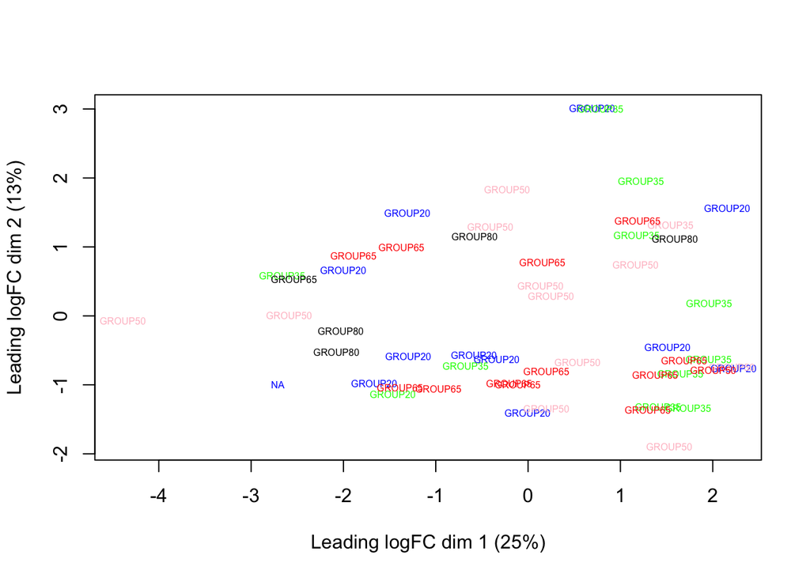

```r
# Examine sample separation in a MDS plot:
short <- sapply(strsplit(colnames(RNAfiltered)[2:54], split = "_"),
                function(x) paste(x[4], collapse = '_'))
plotMDS(d, labels=short, cex=0.5,
        col=c("blue", "green", "pink", "red", "black")[factor(grouping$age)])
```

#### Now examine the “dispersion” of the data:

- ‘**Dispersion**’ describes how much variation there is in the samples. It is a parameter of the negative binomial model commonly used to calculate differential expression. The *“common method”* calculates a dispersion value across all genes, while the *“tagwise method”* calculates gene-specific dispersions. For genes with relatively more counts, they will display smaller variations between samples than genes with fewer counts.
  - Square root of the common dispersion = biological coefficient of variation (**BCV**)

```r
# Estimate Dispersion -->
model_design <- model.matrix(~grouping$sex + grouping$age + 0)
if(!exists('est_d')){
  est_d <- estimateDisp(d, model_design)
}
# Square root of the common dispersion = biological coefficient of variation (BCV)
bcv <- sqrt(est_d$common.dispersion)
bcv
```

```
## [1] 0.8804855
```

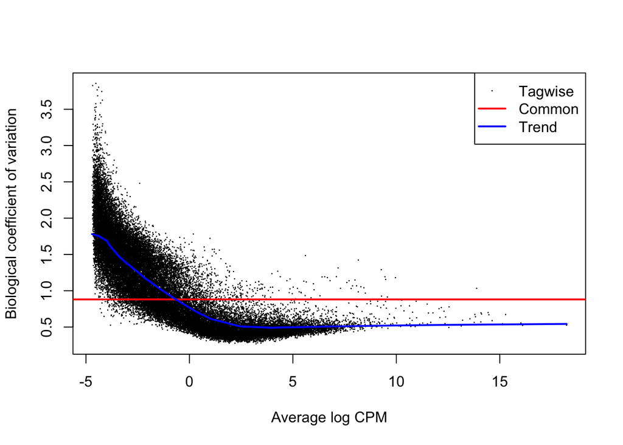

```r
# Plot the relation of genewise BCV versus gene abundance (mean log2 CPM).
plotBCV(est_d,col.tagwise = "black",col.common = "red",)
```

#### Another way of examining data dispersion is to Plot the **mean-variance relationship** of the data:

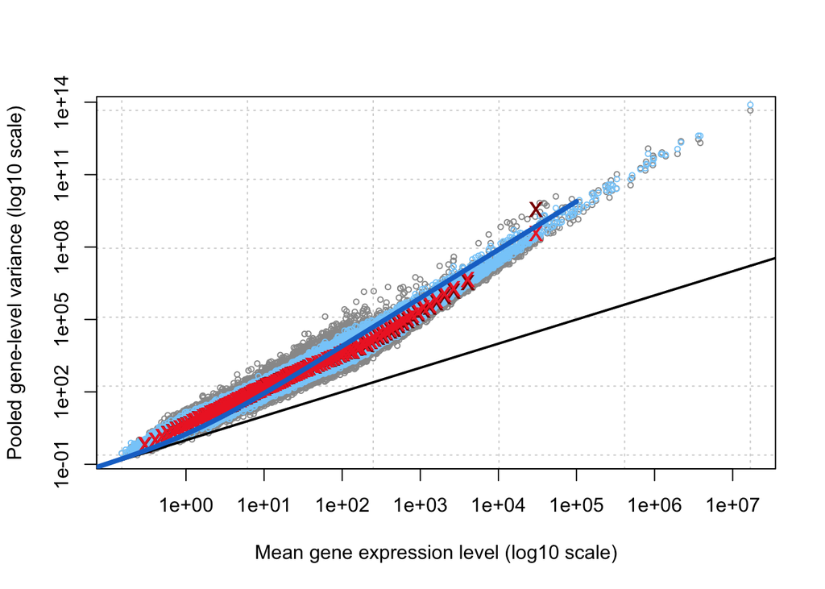

```r
# Plot the mean-variance relationship of the data:
plotMeanVar(est_d, show.raw.vars = TRUE, show.tagwise.vars=TRUE,
            show.ave.raw.vars = TRUE,
            NBline=TRUE,
            show.binned.common.disp.vars = TRUE)
```

#### Alternatively MA plot offers another way of highlighting differentially expressed genes

- plotSmear() in the **edgeR** package produces a type of mean-difference plot (or MA plot) with a special representation (smearing) of log-ratios that are infinite. This plot type resolves the problem of plotting genes that have a total count of zero for one of the groups by adding the ‘smear’ of points at low A value.

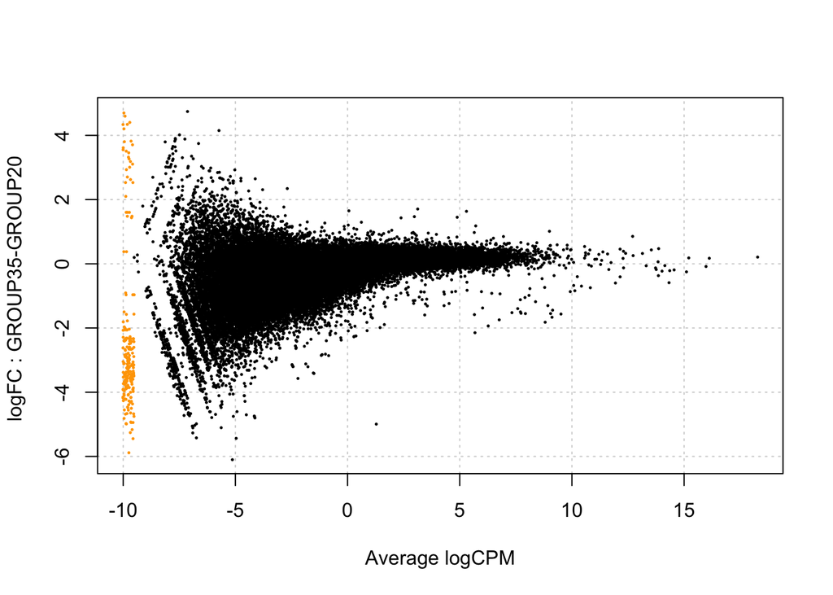

```r
# Alternative graphic summaries of data from the edgeR package:
plotSmear(est_d)
```

#### Volcano plots [first attempt at differencial expression analysis]

- Linear regression analysis was conducted here for our filtered RNA data, it identified 297 RNAs that were overrepresented (p < 0.01, positive β-values for age) and 57 RNAs that were underrepresented (p < 0.01, negative β-values for age) in older compared to younger individuals.
  - Note that the **beta value** in regression refer to the degree of change in the outcome variable for every 1-unit of change in the predictor variable. For our data, a + / - beta value can be used to evaluate the positive / negative changes in gene expression and an outcome of age.
- The volcano plot captures all significant (p < 0.01) RNAs identified by the linear regression model. Red and blue points indicate significant RNAs with positive and negative β-values for age, respectively. Black points denote RNAs with non significant β-values for age.

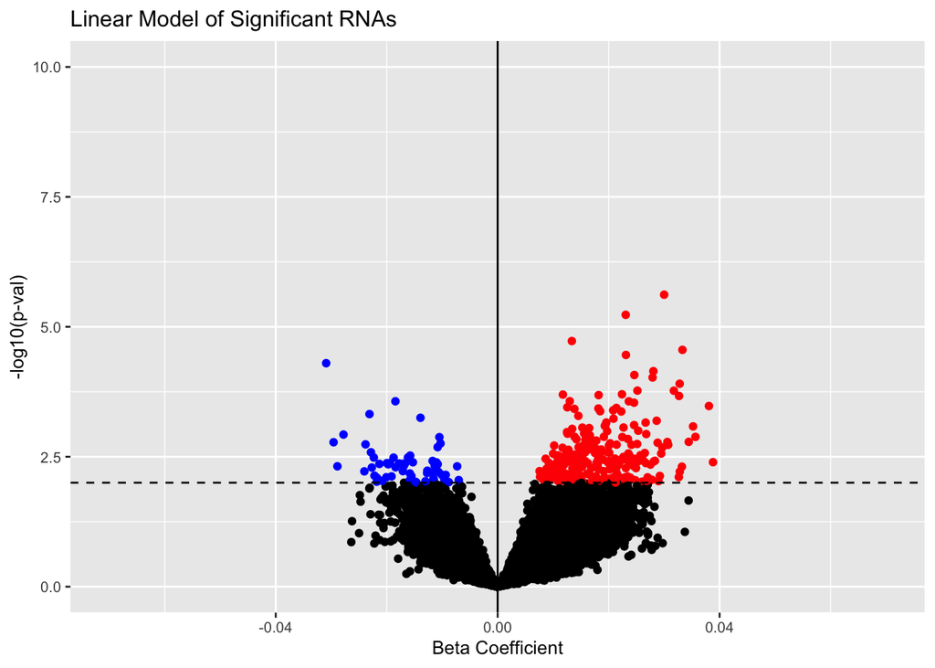

```r
###LINEAR MODEL with age and sex
countspermillion_logged=as.data.frame(cpm(d,log=T))

p.val.lin=numeric()
beta.lin=numeric()
count0=numeric()

Age=c(22,23,25,25,26,26,27,28,31,31,31,33,35,37,37,38,38,42,42,45,45,47,
      47,51,52,52,52,52,54,57,58,60,62,63,63,67,67,67,69,70,70,72,72,72,
      72,72,73,76,80,81,81,81,83)

sex=as.factor(c(1,1,1,0,0,0,0,1,1,1,0,1,
                1,0,1,1,1,0,1,1,1,1,0,
                1,1,0,1,0,1,1,0,1,0,1,0,
                1,1,0,0,1,1,1,0,0,1,1,1,1,
                0,1,1,1,1))

for (i in 1:36084) {
  #print(i)
  model=lm(t(countspermillion_logged[i,])~Age+sex,data=countspermillion_logged)

  p.val.lin[i]=(summary(model)$coefficients[2,4])
  beta.lin[i]=summary(model)$coefficients[2,1]

}

###LINEAR Model volcano plot

lin.info <- data.frame(p.val.lin,beta.lin)
lin.info$threshold <- factor(ifelse(lin.info$p.val.lin<0.01 & lin.info$beta.lin < 0, 1,
                                 ifelse(lin.info$p.val.lin<0.01 & lin.info$beta.lin > 0,-1,0)))
options(scipen=999)  # turn-off scientific notation like 1e+48

linear_Vplot <- ggplot(lin.info, aes(x=beta.lin, y=-log10(p.val.lin))) +
  geom_point(aes(color=lin.info$threshold),show.legend =F)+
  scale_color_manual(values = c("0" = "black", "-1" = "red", "1"="blue"))+
  scale_shape(solid = F)+
  geom_hline(aes(yintercept= -log10(0.01), linetype = "p = 0.01"), colour= 'black',linetype="dashed") +
  geom_vline(xintercept = 0,color="black")+
  xlim(c(-0.07,0.07))+ylim(c(0,10))+
  theme(text = element_text(size=10))+
  labs(y="-log10(p-val)",
       x="Beta Coefficient",
       title = "Linear Model of Significant RNAs"
  )

plot(linear_Vplot)
```

```r
#357 genes, of which 57 have negative betas and 297 have positive betas
neg_betas=which(beta.lin < 0)
over <- length(which(-log10(p.val.lin) >= 2.0))
under <- length(which(-log10(p.val.lin[neg_betas]) >= 2.0))
```